## Data mining example

### Part 1

#### I am using the dataset austen_books() from the package janeaustenr:

```r
library(tidyverse)
library(janeaustenr)
library(tidytext)
```

```r
# assign books to variable name

pride_prejudice <- prideprejudice
sense_sensibility <- sensesensibility
```

#### 1. I am going to look for the most common words in Pride & Prejudice and Sense & Sensibility.

#### 1a. Pride and Prejudice

```r
pride_prejudice_text <- tibble(
  phrase = pride_prejudice,
  id     = 1:length(pride_prejudice)
)
head(pride_prejudice_text)
```

```
## # A tibble: 6 x 2
##   phrase                 id
##   <chr>               <int>
## 1 PRIDE AND PREJUDICE     1
## 2 ""                      2
## 3 By Jane Austen          3
## 4 ""                      4
## 5 ""                      5
## 6 ""                      6
```

```r
words_pride_and_prejudice <-
pride_prejudice_text %>%
  unnest_tokens(word, phrase)

words_pride_and_prejudice
```

```
## # A tibble: 122,204 x 2
##       id word
##    <int> <chr>
##  1     1 pride
##  2     1 and
##  3     1 prejudice
##  4     3 by
##  5     3 jane
##  6     3 austen
##  7     7 chapter
##  8     7 1
##  9    10 it
## 10    10 is
## # … with 122,194 more rows
```

```r
# the most common words in pride and prejudice are below, arranged in descending order from the most common to the least common.
words_pride_and_prejudice %>%
  group_by(word) %>%
  summarise(
    count = n()
  ) %>%
   arrange(desc(count))
```

```
## # A tibble: 6,538 x 2
##    word  count
##    <chr> <int>
##  1 the    4331
##  2 to     4162
##  3 of     3610
##  4 and    3585
##  5 her    2203
##  6 i      2065
##  7 a      1954
##  8 in     1880
##  9 was    1843
## 10 she    1695
## # … with 6,528 more rows
```

#### 1b. Sense and sensibility

```r
sense_sensibility_text <- tibble(
  phrase = sense_sensibility,
  id     = 1:length(sense_sensibility)
)
head(sense_sensibility_text)
```

```
## # A tibble: 6 x 2
##   phrase                   id
##   <chr>                 <int>
## 1 SENSE AND SENSIBILITY     1
## 2 ""                        2
## 3 by Jane Austen            3
## 4 ""                        4
## 5 (1811)                    5
## 6 ""                        6
```

```r
words_sense_sensibility <-
sense_sensibility_text %>%
  unnest_tokens(word, phrase)

words_sense_sensibility
```

```
## # A tibble: 119,957 x 2
##       id word
##    <int> <chr>
##  1     1 sense
##  2     1 and
##  3     1 sensibility
##  4     3 by
##  5     3 jane
##  6     3 austen
##  7     5 1811
##  8    10 chapter
##  9    10 1
## 10    13 the
## # … with 119,947 more rows
```

```r
# the most common words in pride and prejudice are below, arranged in descending order from the most common to the least common.
words_sense_sensibility %>%
  group_by(word) %>%
  summarise(
    count = n()
  ) %>%
   arrange(desc(count))
```

```
## # A tibble: 6,419 x 2
##    word  count
##    <chr> <int>
##  1 to     4116
##  2 the    4105
##  3 of     3571
##  4 and    3490
##  5 her    2543
##  6 a      2092
##  7 i      1998
##  8 in     1979
##  9 was    1861
## 10 it     1755
## # … with 6,409 more rows
```

#### 2. I am going to look for the most common words in Pride & Prejudice and Sense & Sensibility, not including stop words (stop words are very common words such as ‘the’, ‘a’, ‘and’ etc)

#### 2a. Pride and prejudice

```r
# I am doing an anti-join between the stop_words df found in the tidytext package and the book I am analysing. This will keep only the words which are not stop words.
words_pride_and_prejudice %>%
  anti_join(stop_words) %>%
  count(word, sort = TRUE)
```

```
## # A tibble: 6,009 x 2
##    word          n
##    <chr>     <int>
##  1 elizabeth   597
##  2 darcy       373
##  3 bennet      294
##  4 miss        283
##  5 jane        264
##  6 bingley     257
##  7 time        203
##  8 lady        183
##  9 sister      180
## 10 wickham     162
## # … with 5,999 more rows
```

#### 2b. Sense and sensibility

```r
words_sense_sensibility %>%
  anti_join(stop_words) %>%
  count(word, sort = TRUE)
```

```
## # A tibble: 5,897 x 2
##    word           n
##    <chr>      <int>
##  1 elinor       623
##  2 marianne     492
##  3 time         239
##  4 dashwood     231
##  5 sister       229
##  6 edward       220
##  7 mother       213
##  8 miss         210
##  9 jennings     199
## 10 willoughby   181
## # … with 5,887 more rows
```

#### 3. I am going to look for the most common sentiment words in Pride & Prejudice and Sense & Sensibility. Sentiment words are those which evoke feelings such as anger, hapiness etc. There are different sentiment analysis lexicons such as ‘afinn’, ‘bing’, ‘loughran’ and ‘nrc’. I will not use ‘nrc’ for this purpose as it is quite large to download, so I will use one of the other ones mentioned above.

#### 3a. Pride and prejudice

```r
# this shows a left join between the sentiment words from the 'bing' lexicon and the words found in the book. Notice not all words have a sentiment attached to them, these appear as NA.
words_pride_and_prejudice %>%
  left_join(get_sentiments("bing"))
```

```
## # A tibble: 122,204 x 3
##       id word      sentiment
##    <int> <chr>     <chr>
##  1     1 pride     positive
##  2     1 and       <NA>
##  3     1 prejudice negative
##  4     3 by        <NA>
##  5     3 jane      <NA>
##  6     3 austen    <NA>
##  7     7 chapter   <NA>
##  8     7 1         <NA>
##  9    10 it        <NA>
## 10    10 is        <NA>
## # … with 122,194 more rows
```

```r
# now I want to keep just those words which have a sentiment, so I did an inner join.
words_pride_and_prejudice %>%
  inner_join(get_sentiments("bing"))
```

```
## # A tibble: 8,704 x 3
##       id word        sentiment
##    <int> <chr>       <chr>
##  1     1 pride       positive
##  2     1 prejudice   negative
##  3    11 good        positive
##  4    11 fortune     positive
##  5    14 well        positive
##  6    15 rightful    positive
##  7    28 impatiently negative
##  8    30 objection   negative
##  9    32 enough      positive
## 10    35 fortune     positive
## # … with 8,694 more rows
```

```r
# Now I want to sort them and find the most common sentiment words

# creating data frame with all sentiment words
sentiment_words_p_and_p <-
words_pride_and_prejudice %>%
  inner_join(get_sentiments("bing"))
```

```r
# filter for the most common positive words
sentiment_words_p_and_p %>%
  filter(sentiment == "positive") %>%
  count(word, sort = TRUE)
```

```
## # A tibble: 592 x 2
##    word          n
##    <chr>     <int>
##  1 well        224
##  2 good        200
##  3 great       142
##  4 enough      106
##  5 better       92
##  6 love         92
##  7 pleasure     92
##  8 happy        83
##  9 like         77
## 10 happiness    72
## # … with 582 more rows
```

```r
# filter for the most common negative words
sentiment_words_p_and_p %>%
  filter(sentiment == "negative") %>%
  count(word, sort = TRUE)
```

```
## # A tibble: 838 x 2
##    word           n
##    <chr>      <int>
##  1 miss         283
##  2 object        48
##  3 scarcely      45
##  4 impossible    44
##  5 poor          38
##  6 afraid        37
##  7 doubt         37
##  8 sorry         34
##  9 lost          29
## 10 pain          28
## # … with 828 more rows
```

#### 3b. Sense and sensibility

```r
# this shows a left join between the sentiment words from the 'bing' lexicon and the words found in the book. Notice not all words have a sentiment attached to them, these appear as NA.
words_sense_sensibility %>%
  left_join(get_sentiments("bing"))
```

```
## # A tibble: 119,957 x 3
##       id word        sentiment
##    <int> <chr>       <chr>
##  1     1 sense       <NA>
##  2     1 and         <NA>
##  3     1 sensibility <NA>
##  4     3 by          <NA>
##  5     3 jane        <NA>
##  6     3 austen      <NA>
##  7     5 1811        <NA>
##  8    10 chapter     <NA>
##  9    10 1           <NA>
## 10    13 the         <NA>
## # … with 119,947 more rows
```

```r
# now I want to keep just those words which have a sentiment, so I did an inner join.
words_sense_sensibility %>%
  inner_join(get_sentiments("bing"))
```

```
## # A tibble: 8,604 x 3
##       id word        sentiment
##    <int> <chr>       <chr>
##  1    16 respectable positive
##  2    16 good        positive
##  3    18 advanced    positive
##  4    20 death       negative
##  5    20 great       positive
##  6    21 loss        negative
##  7    25 comfortably positive
##  8    28 goodness    positive
##  9    28 solid       positive
## 10    29 comfort     positive
## # … with 8,594 more rows
```

```r
# now I want to sort them and find the most common sentiment words

# creating a data frame with all sentiment words
sentiment_words_s_and_s <-
words_sense_sensibility %>%
  inner_join(get_sentiments("bing"))
```

```r
# filter for the most common positive words
sentiment_words_s_and_s %>%
  filter(sentiment == "positive") %>%
  count(word, sort = TRUE)
```

```
## # A tibble: 593 x 2
##    word          n
##    <chr>     <int>
##  1 well        240
##  2 good        177
##  3 great       149
##  4 enough      103
##  5 happy       100
##  6 like         83
##  7 affection    79
##  8 better       78
##  9 love         77
## 10 pleasure     67
## # … with 583 more rows
```

```r
# filter for the most common negative words
sentiment_words_s_and_s %>%
  filter(sentiment == "negative") %>%
  count(word, sort = TRUE)
```

```
## # A tibble: 840 x 2
##    word           n
##    <chr>      <int>
##  1 miss         210
##  2 poor          71
##  3 doubt         46
##  4 object        37
##  5 impossible    36
##  6 spite         35
##  7 sorry         34
##  8 anxious       29
##  9 concern       28
## 10 misery        28
## # … with 830 more rows
```

> It seems that in both books, the most common sentiment words are quite similar.

#### Based on the above analysis, I will create two plots which visualise the differences between the two books.

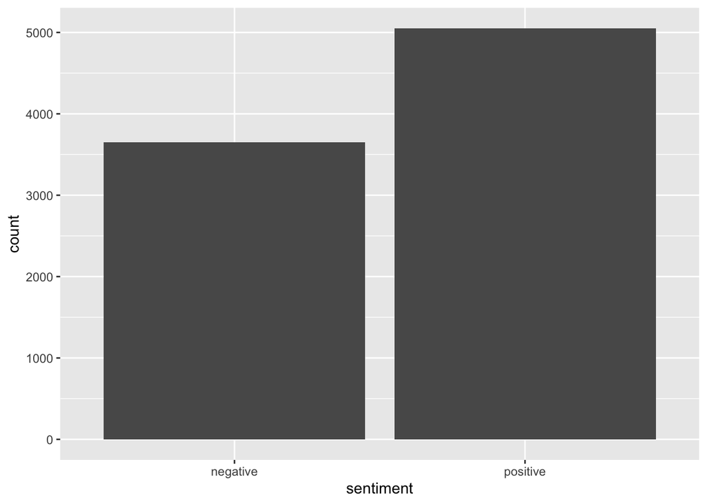

```r
sentiment_words_p_and_p %>%
  ggplot() +
  aes(x = sentiment) +
  geom_bar()
```

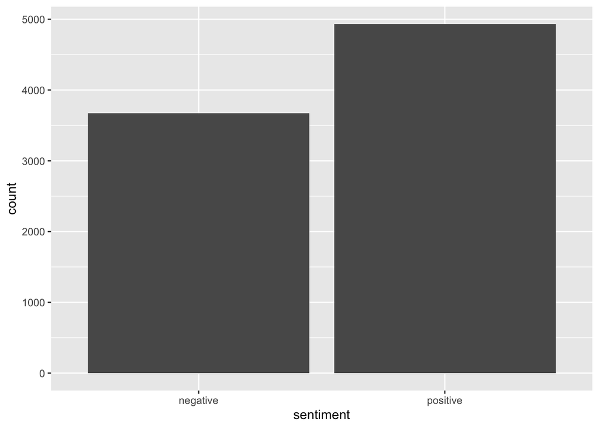

```r
sentiment_words_s_and_s %>%
  ggplot() +
  aes(x = sentiment) +
  geom_bar()
```

> The plots look very similar in terms of sentiments used in each book, with slightly more positive words used in Pride and Prejudice.